# Datos multidimensionales

Martin Malo

22/7/2021

# Datos multidimensionales

### Ejemplo con 3 dimensiones

```r
ans <- sample(c("Si", "No"), size = 100, replace = TRUE)
sex <- sample(c("H", "M"), size = 100, replace = TRUE)
place <- sample(c("San Francisco", "Barcelona", "Valencia", "Cobija", "Asturias"),
                size = 100, replace = TRUE)
table(sex, ans, place)
```

```
## , , place = Asturias
##
##    ans
## sex No Si
##   H  6  6
##   M  5  4
##
## , , place = Barcelona
##
##    ans
## sex No Si
##   H  2  3
##   M  9  3
##
## , , place = Cobija
##
##    ans
## sex No Si
##   H  5  6
##   M  6  9
##
## , , place = San Francisco
##
##    ans
## sex No Si
##   H  6  9
##   M  3  4
##
## , , place = Valencia
##
##    ans
## sex No Si
##   H  3  5
##   M  3  3
```

```r
ftable(sex,ans,place)
```

```
##         place Asturias Barcelona Cobija San Francisco Valencia
## sex ans
## H   No               6         2      5             6        3
##     Si               6         3      6             9        5
## M   No               5         9      6             3        3
##     Si               4         3      9             4        3
```

```r
ftable(sex,ans,place, col.vars = c("sex", "ans"))
```

```
##               sex  H     M
##               ans No Si No Si
## place
## Asturias           6  6  5  4
## Barcelona          2  3  9  3
## Cobija             5  6  6  9
## San Francisco      6  9  3  4
## Valencia           3  5  3  3
```

#### Filtrar las tablas

```r
table(sex, ans, place)["M", "No", "Valencia"]
```

```
## [1] 3
```

```r
table(sex, ans, place)[ , "Si", "Barcelona"]
```

```
## H M
## 3 3
```

```r
table(sex, ans, place)[ , , "Asturias"]
```

```
##    ans
## sex No Si
##   H  6  6
##   M  5  4
```

```r
table(sex, ans, place)[ , "No", ]
```

```
##    place
## sex Asturias Barcelona Cobija San Francisco Valencia
##   H        6         2      5             6        3
##   M        5         9      6             3        3
```

```r
table(sex, ans, place)["H", , ]
```

```
##     place
## ans  Asturias Barcelona Cobija San Francisco Valencia
##   No        6         2      5             6        3
##   Si        6         3      6             9        5
```

#### Frecuencias relativas

```r
prop.table(table(sex,ans,place)) # Frecuencias relativas globales
```

```
## , , place = Asturias
##
##    ans
## sex   No   Si
##   H 0.06 0.06
##   M 0.05 0.04
##
## , , place = Barcelona
##
##    ans
## sex   No   Si
##   H 0.02 0.03
##   M 0.09 0.03
##
## , , place = Cobija
##
##    ans
## sex   No   Si
##   H 0.05 0.06
##   M 0.06 0.09
##
## , , place = San Francisco
##
##    ans
## sex   No   Si
##   H 0.06 0.09
##   M 0.03 0.04
##
## , , place = Valencia
##
##    ans
## sex   No   Si
##   H 0.03 0.05
##   M 0.03 0.03
```

```r
prop.table(table(sex,ans,place), margin = 3) # Frecuencias relativa marginal por place
```

```
## , , place = Asturias
##
##    ans
## sex        No        Si
##   H 0.2857143 0.2857143
##   M 0.2380952 0.1904762
##
## , , place = Barcelona
##
##    ans
## sex        No        Si
##   H 0.1176471 0.1764706
##   M 0.5294118 0.1764706
##
## , , place = Cobija
##
##    ans
## sex        No        Si
##   H 0.1923077 0.2307692
##   M 0.2307692 0.3461538
##
## , , place = San Francisco
##
##    ans
## sex        No        Si
##   H 0.2727273 0.4090909
##   M 0.1363636 0.1818182
##
## , , place = Valencia
##
##    ans
## sex        No        Si
##   H 0.2142857 0.3571429
##   M 0.2142857 0.2142857
```

```r
prop.table(table(sex,ans,place), margin = c(1,3)) # Frecuencias relativa marginal por sexp y place
```

```
## , , place = Asturias
##
##    ans
## sex        No        Si
##   H 0.5000000 0.5000000
##   M 0.5555556 0.4444444
##
## , , place = Barcelona
##
##    ans
## sex        No        Si
##   H 0.4000000 0.6000000
##   M 0.7500000 0.2500000
##
## , , place = Cobija
##
##    ans
## sex        No        Si
##   H 0.4545455 0.5454545
##   M 0.4000000 0.6000000
##
## , , place = San Francisco
##
##    ans
## sex        No        Si
##   H 0.4000000 0.6000000
##   M 0.4285714 0.5714286
##
## , , place = Valencia
##
##    ans
## sex        No        Si
##   H 0.3750000 0.6250000
##   M 0.5000000 0.5000000
```

```r
ftable(prop.table(table(sex,ans,place)), col.vars = c("sex", "ans"))
```

```
##               sex    H         M
##               ans   No   Si   No   Si
## place
## Asturias          0.06 0.06 0.05 0.04
## Barcelona         0.02 0.03 0.09 0.03
## Cobija            0.05 0.06 0.06 0.09
## San Francisco     0.06 0.09 0.03 0.04
## Valencia          0.03 0.05 0.03 0.03
```

# Datos HairEyeColor

```r
HairEyeColor
```

```
## , , Sex = Male
##
##        Eye
## Hair    Brown Blue Hazel Green
##   Black    32   11    10     3
##   Brown    53   50    25    15
##   Red      10   10     7     7
##   Blond     3   30     5     8
##
## , , Sex = Female
##
##        Eye
## Hair    Brown Blue Hazel Green
##   Black    36    9     5     2
##   Brown    66   34    29    14
##   Red      16    7     7     7
##   Blond     4   64     5     8
```

```r
total <- sum(HairEyeColor)
```

El total de individuos del estudio es 592

```r
prop.table(HairEyeColor, margin = 3)
```

```
## , , Sex = Male
##
##        Eye
## Hair          Brown        Blue       Hazel       Green
##   Black 0.114695341 0.039426523 0.035842294 0.010752688
##   Brown 0.189964158 0.179211470 0.089605735 0.053763441
##   Red   0.035842294 0.035842294 0.025089606 0.025089606
##   Blond 0.010752688 0.107526882 0.017921147 0.028673835
##
## , , Sex = Female
##
##        Eye
## Hair          Brown        Blue       Hazel       Green
##   Black 0.115015974 0.028753994 0.015974441 0.006389776
##   Brown 0.210862620 0.108626198 0.092651757 0.044728435
##   Red   0.051118211 0.022364217 0.022364217 0.022364217
##   Blond 0.012779553 0.204472843 0.015974441 0.025559105
```

```r
prop.table(HairEyeColor, margin = c(1,2))
```

```
## , , Sex = Male
##
##        Eye
## Hair        Brown      Blue     Hazel     Green
##   Black 0.4705882 0.5500000 0.6666667 0.6000000
##   Brown 0.4453782 0.5952381 0.4629630 0.5172414
##   Red   0.3846154 0.5882353 0.5000000 0.5000000
##   Blond 0.4285714 0.3191489 0.5000000 0.5000000
##
## , , Sex = Female
##
##        Eye
## Hair        Brown      Blue     Hazel     Green
##   Black 0.5294118 0.4500000 0.3333333 0.4000000
##   Brown 0.5546218 0.4047619 0.5370370 0.4827586
##   Red   0.6153846 0.4117647 0.5000000 0.5000000
##   Blond 0.5714286 0.6808511 0.5000000 0.5000000
```

```r
aperm(HairEyeColor, perm = c("Sex", "Hair", "Eye"))
```

```
## , , Eye = Brown
##
##         Hair
## Sex      Black Brown Red Blond
##   Male      32    53  10     3
##   Female    36    66  16     4
##
## , , Eye = Blue
##
##         Hair
## Sex      Black Brown Red Blond
##   Male      11    50  10    30
##   Female     9    34   7    64
##
## , , Eye = Hazel
##
##         Hair
## Sex      Black Brown Red Blond
##   Male      10    25   7     5
##   Female     5    29   7     5
##
## , , Eye = Green
##
##         Hair
## Sex      Black Brown Red Blond
##   Male       3    15   7     8
##   Female     2    14   7     8
```

```r
knitr::kable(HairEyeColor)
```

| Hair | Eye | Sex | Freq |
| --- | --- | --- | --- |
| Black | Brown | Male | 32 |
| Brown | Brown | Male | 53 |
| Red | Brown | Male | 10 |
| Blond | Brown | Male | 3 |
| Black | Blue | Male | 11 |
| Brown | Blue | Male | 50 |
| Red | Blue | Male | 10 |
| Blond | Blue | Male | 30 |
| Black | Hazel | Male | 10 |
| Brown | Hazel | Male | 25 |
| Red | Hazel | Male | 7 |
| Blond | Hazel | Male | 5 |
| Black | Green | Male | 3 |
| Brown | Green | Male | 15 |
| Red | Green | Male | 7 |
| Blond | Green | Male | 8 |
| Black | Brown | Female | 36 |
| Brown | Brown | Female | 66 |
| Red | Brown | Female | 16 |
| Blond | Brown | Female | 4 |
| Black | Blue | Female | 9 |
| Brown | Blue | Female | 34 |
| Red | Blue | Female | 7 |
| Blond | Blue | Female | 64 |
| Black | Hazel | Female | 5 |
| Brown | Hazel | Female | 29 |
| Red | Hazel | Female | 7 |
| Blond | Hazel | Female | 5 |
| Black | Green | Female | 2 |
| Brown | Green | Female | 14 |
| Red | Green | Female | 7 |
| Blond | Green | Female | 8 |

#Tablas a partir de datos cualitativos

###Ejemplo de bebidad energeticas

```r
beb_energy <- read.table("../../data/EnergyDrink", stringsAsFactors = T, header = T)
str(beb_energy)
```

```
## 'data.frame':    122 obs. of  3 variables:
##  $ estudio: Factor w/ 4 levels "Industriales",..: 2 3 1 2 1 3 2 1 2 2 ...
##  $ bebe   : Factor w/ 2 levels "No","Si": 1 1 2 2 1 1 2 1 1 1 ...
##  $ sexo   : Factor w/ 2 levels "Hombre","Mujer": 2 1 2 1 2 2 1 1 1 1 ...
```

```r
head(beb_energy)
```

```
##        estudio bebe   sexo
## 1  Informatica   No  Mujer
## 2        Mates   No Hombre
## 3 Industriales   Si  Mujer
## 4  Informatica   Si Hombre
## 5 Industriales   No  Mujer
## 6        Mates   No  Mujer
```

```r
summary(beb_energy)
```

```
##          estudio   bebe        sexo
##  Industriales:37   No:97   Hombre:83
##  Informatica :53   Si:25   Mujer :39
##  Mates       :16
##  Telematica  :16
```

```r
apply(beb_energy, MARGIN = 2, FUN = table)
```

```
## $estudio
##
## Industriales  Informatica        Mates   Telematica
##           37           53           16           16
##
## $bebe
##
## No Si
## 97 25
##
## $sexo
##
## Hombre  Mujer
##     83     39
```

```r
apply(beb_energy, MARGIN = 2, FUN = table)$sexo
```

```
##
## Hombre  Mujer
##     83     39
```

```r
#Equivalente:
table(beb_energy$sexo)
```

```
##
## Hombre  Mujer
##     83     39
```

```r
table(beb_energy)
```

```
## , , sexo = Hombre
##
##               bebe
## estudio        No Si
##   Industriales 19  6
##   Informatica  30  7
##   Mates         8  1
##   Telematica   10  2
##
## , , sexo = Mujer
##
##               bebe
## estudio        No Si
##   Industriales 10  2
##   Informatica  11  5
##   Mates         6  1
##   Telematica    3  1
```

```r
table(beb_energy[c(1,3)])
```

```
##               sexo
## estudio        Hombre Mujer
##   Industriales     25    12
##   Informatica      37    16
##   Mates             9     7
##   Telematica       12     4
```

```r
ftable(beb_energy)
```

```
##                   sexo Hombre Mujer
## estudio      bebe
## Industriales No            19    10
##              Si             6     2
## Informatica  No            30    11
##              Si             7     5
## Mates        No             8     6
##              Si             1     1
## Telematica   No            10     3
##              Si             2     1
```

#Diagramas de barras

Se utiliza la funcion `barplot()`. Para introducir datos hay que utilizar la funcion `table()` y si queremos ver los datos relativos hay que aplicar `prop.table(table())`. Para ver las barras de forma horizontal hay que usar el parametro `horiz = TRUE`. El parametro `args.legend =` imita a la funcion `legend()`. Al usar dos tipos de datos diferentes, la funcion va a tomar como principal a la que se coloque en la segunda posicion.

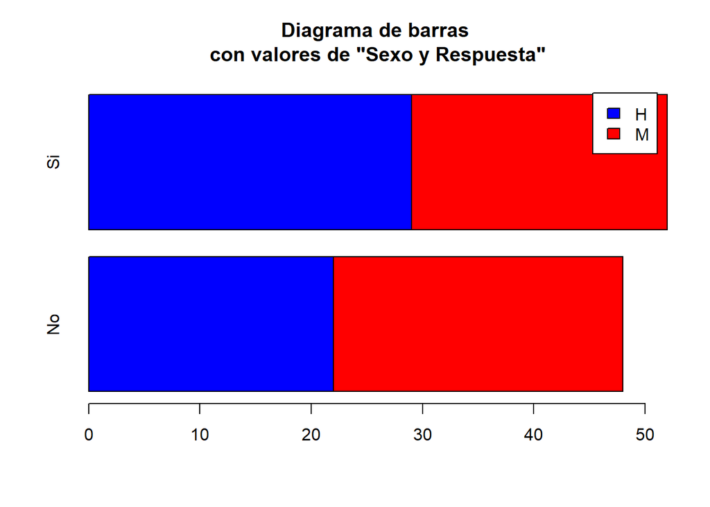

```r
barplot(table(sex,ans), main = "Diagrama de barras\n con valores de \"Sexo y Respuesta\"",
        col = c("blue", "red"), legend.text = T, horiz = T)
```

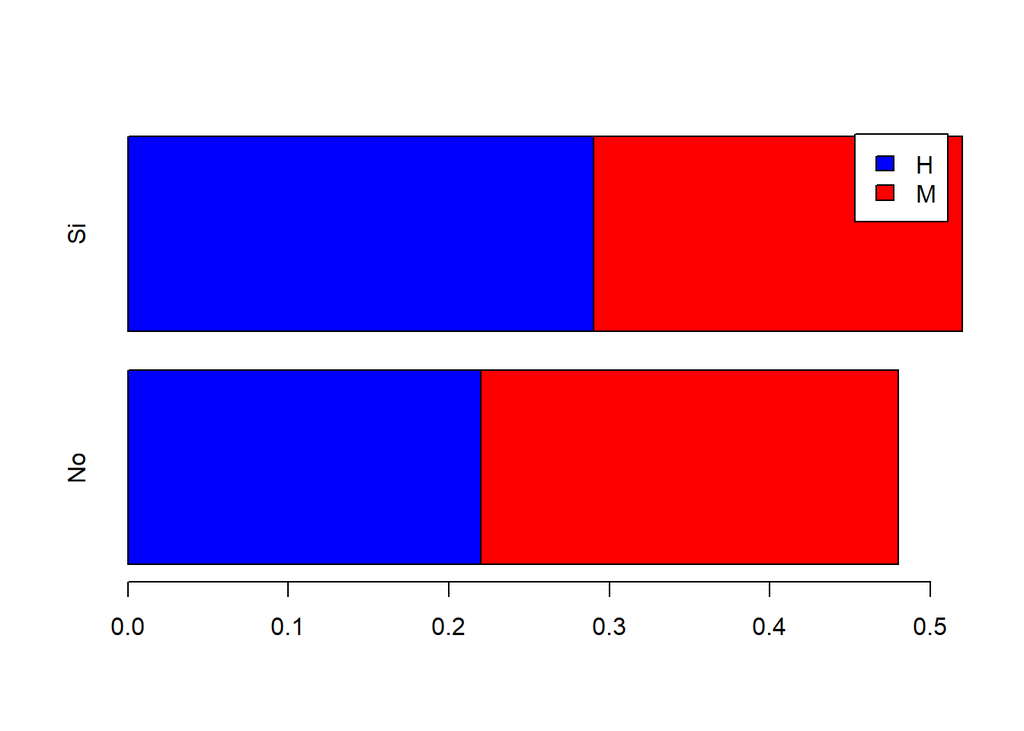

```r
barplot(prop.table(table(sex,ans)), col = c("blue", "red"), legend.text = T, horiz = T)
```

#Diagrmas circulares

Para usar estos graficos se utiliza la funcion `pie()` y utiliza algunos de los parametros de la funcion `barplot()`.

#Diagramas de mosaico

En el diagrama de mosico las variables tienen sus reglas. La primera regal va a dividir verticalmente a las barras, la segunda variable va a darle su altura y la tercera varibale va a darle su anchura. Este ejemplo muestra que la primera variable(Hair) divide la barras verticalmente, la segunda variable(Eye) define la altura y la tercera varibale(genero) define la anchura de las barras.

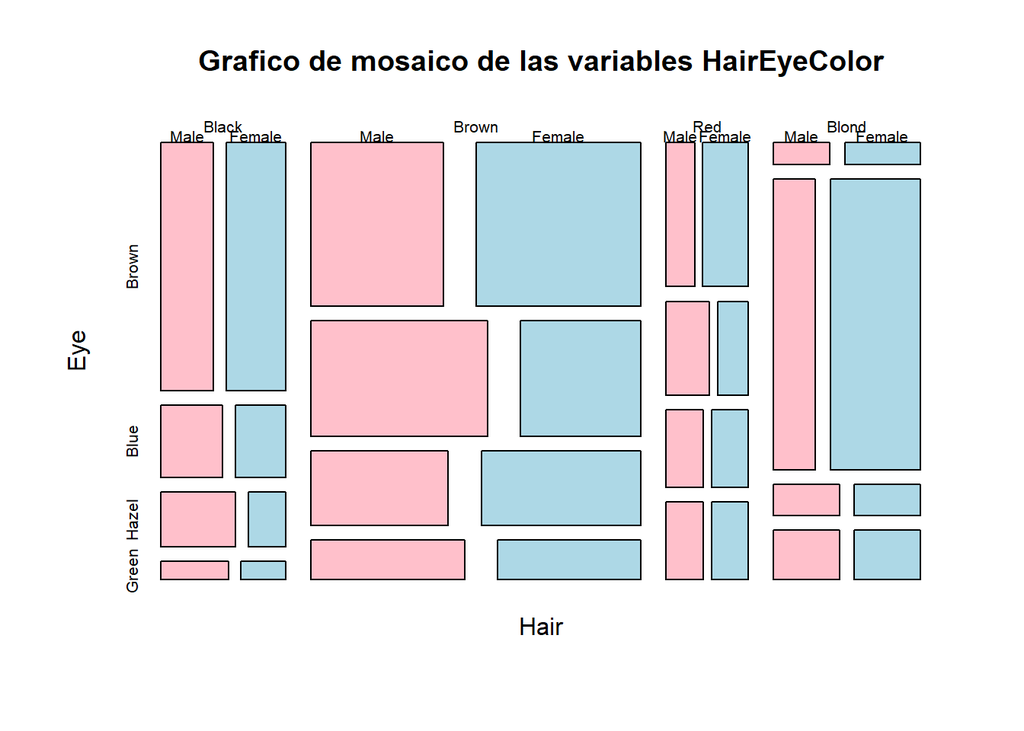

```r
plot(HairEyeColor, main = "Grafico de mosaico de las variables HairEyeColor",
     col = c("pink", "lightblue"))
```

```r
HairEyeColor
```

```
## , , Sex = Male
##
##        Eye
## Hair    Brown Blue Hazel Green
##   Black    32   11    10     3
##   Brown    53   50    25    15
##   Red      10   10     7     7
##   Blond     3   30     5     8
##
## , , Sex = Female
##
##        Eye
## Hair    Brown Blue Hazel Green
##   Black    36    9     5     2
##   Brown    66   34    29    14
##   Red      16    7     7     7
##   Blond     4   64     5     8
```

`mosaic3d()` grafica en 3D, pero instalando el paquete rgl. `cotabplot()` permite ver de una mejora manera un grafico multidimensional

#Ejemplo final

### JUntar color de ojos y pelo sin distinguir sexo

```r
HairEyeColor
```

```
## , , Sex = Male
##
##        Eye
## Hair    Brown Blue Hazel Green
##   Black    32   11    10     3
##   Brown    53   50    25    15
##   Red      10   10     7     7
##   Blond     3   30     5     8
##
## , , Sex = Female
##
##        Eye
## Hair    Brown Blue Hazel Green
##   Black    36    9     5     2
##   Brown    66   34    29    14
##   Red      16    7     7     7
##   Blond     4   64     5     8
```

```r
male <- HairEyeColor[, , "Male"]
female <- HairEyeColor[, , "Female"]
data <- as.table(male + female)
```

## Manipulacion de datos

```r
dimnames(data) <- list(
  Pelo = c("Negro", "Marrón", "Pelirrojo", "Rubio"),
  Ojos = c("Marrón", "Azul", "Avellana", "Verde")
  )
data
```

```
##            Ojos
## Pelo        Marrón Azul Avellana Verde
##   Negro         68   20       15     5
##   Marrón       119   84       54    29
##   Pelirrojo     26   17       14    14
##   Rubio          7   94       10    16
```

## Diagrama de mosaico

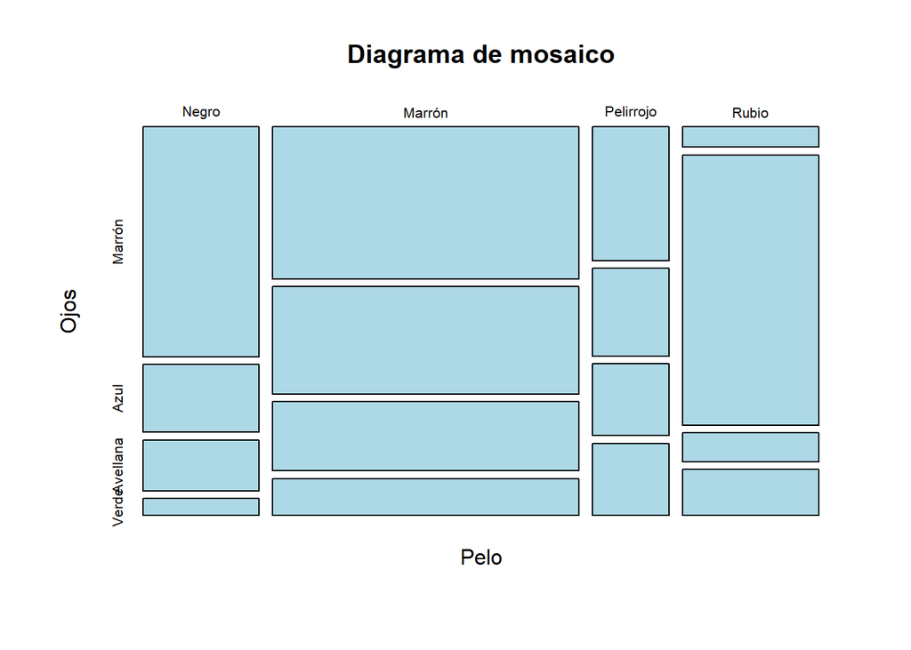

```r
plot(data, main = "Diagrama de mosaico", col = "lightblue")
```

## Numero total de individuos

```r
sum(data)
```

```
## [1] 592
```

## Frecuencias absolutas y relativas

```r
colSums(data)
```

```
##   Marrón     Azul Avellana    Verde
##      220      215       93       64
```

```r
rowSums(data)
```

```
##     Negro    Marrón Pelirrojo     Rubio
##       108       286        71       127
```

```r
round(prop.table(colSums(data)), 3)
```

```
##   Marrón     Azul Avellana    Verde
##    0.372    0.363    0.157    0.108
```

```r
round(prop.table(rowSums(data)), 3)
```

```
##     Negro    Marrón Pelirrojo     Rubio
##     0.182     0.483     0.120     0.215
```

## Representacion en diagrama de barras

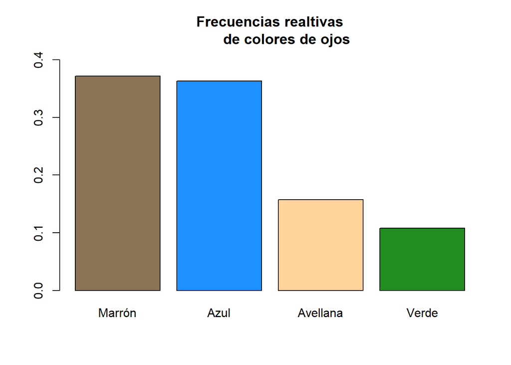

```r
barplot(prop.table(colSums(data)), main = "Frecuencias realtivas
        de colores de ojos", col = c("burlywood4", "dodgerblue", "burlywood1",
                                     "forestgreen"),
        ylim = c(0, 0.4))
```

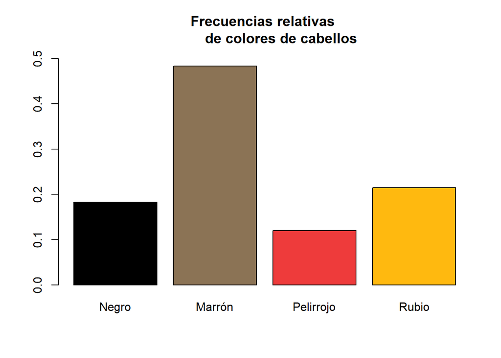

```r
barplot(prop.table(rowSums(data)), main = "Frecuencias relativas
        de colores de cabellos", col = c("black", "burlywood4", "brown2",
                                         "darkgoldenrod1"),
        ylim = c(0, 0.5))
```

## Frecuencias realtivas

```r
round(prop.table(data), 4) #Global
```

```
##            Ojos
## Pelo        Marrón   Azul Avellana  Verde
##   Negro     0.1149 0.0338   0.0253 0.0084
##   Marrón    0.2010 0.1419   0.0912 0.0490
##   Pelirrojo 0.0439 0.0287   0.0236 0.0236
##   Rubio     0.0118 0.1588   0.0169 0.0270
```

```r
round(prop.table(data, margin = 1), 3) #Por color de pelo
```

```
##            Ojos
## Pelo        Marrón  Azul Avellana Verde
##   Negro      0.630 0.185    0.139 0.046
##   Marrón     0.416 0.294    0.189 0.101
##   Pelirrojo  0.366 0.239    0.197 0.197
##   Rubio      0.055 0.740    0.079 0.126
```

```r
round(prop.table(data, margin = 2), 3) #Por color de ojos
```

```
##            Ojos
## Pelo        Marrón  Azul Avellana Verde
##   Negro      0.309 0.093    0.161 0.078
##   Marrón     0.541 0.391    0.581 0.453
##   Pelirrojo  0.118 0.079    0.151 0.219
##   Rubio      0.032 0.437    0.108 0.250
```

```r
#No se utiliza table luego de prop.table ya que data, ya es una tabla. Si esta no fuera una tabla tendria que usarse

library(gmodels)
CrossTable(data, prop.chisq = F)
```

```
##
##
##    Cell Contents
## |-------------------------|
## |                       N |
## |           N / Row Total |
## |           N / Col Total |
## |         N / Table Total |
## |-------------------------|
##
##
## Total Observations in Table:  592
##
##
##              | Ojos
##         Pelo |    Marrón |      Azul |  Avellana |     Verde | Row Total |
## -------------|-----------|-----------|-----------|-----------|-----------|
##        Negro |        68 |        20 |        15 |         5 |       108 |
##              |     0.630 |     0.185 |     0.139 |     0.046 |     0.182 |
##              |     0.309 |     0.093 |     0.161 |     0.078 |           |
##              |     0.115 |     0.034 |     0.025 |     0.008 |           |
## -------------|-----------|-----------|-----------|-----------|-----------|
##       Marrón |       119 |        84 |        54 |        29 |       286 |
##              |     0.416 |     0.294 |     0.189 |     0.101 |     0.483 |
##              |     0.541 |     0.391 |     0.581 |     0.453 |           |
##              |     0.201 |     0.142 |     0.091 |     0.049 |           |
## -------------|-----------|-----------|-----------|-----------|-----------|
##    Pelirrojo |        26 |        17 |        14 |        14 |        71 |
##              |     0.366 |     0.239 |     0.197 |     0.197 |     0.120 |
##              |     0.118 |     0.079 |     0.151 |     0.219 |           |
##              |     0.044 |     0.029 |     0.024 |     0.024 |           |
## -------------|-----------|-----------|-----------|-----------|-----------|
##        Rubio |         7 |        94 |        10 |        16 |       127 |
##              |     0.055 |     0.740 |     0.079 |     0.126 |     0.215 |
##              |     0.032 |     0.437 |     0.108 |     0.250 |           |
##              |     0.012 |     0.159 |     0.017 |     0.027 |           |
## -------------|-----------|-----------|-----------|-----------|-----------|
## Column Total |       220 |       215 |        93 |        64 |       592 |
##              |     0.372 |     0.363 |     0.157 |     0.108 |           |
## -------------|-----------|-----------|-----------|-----------|-----------|
##
##
```

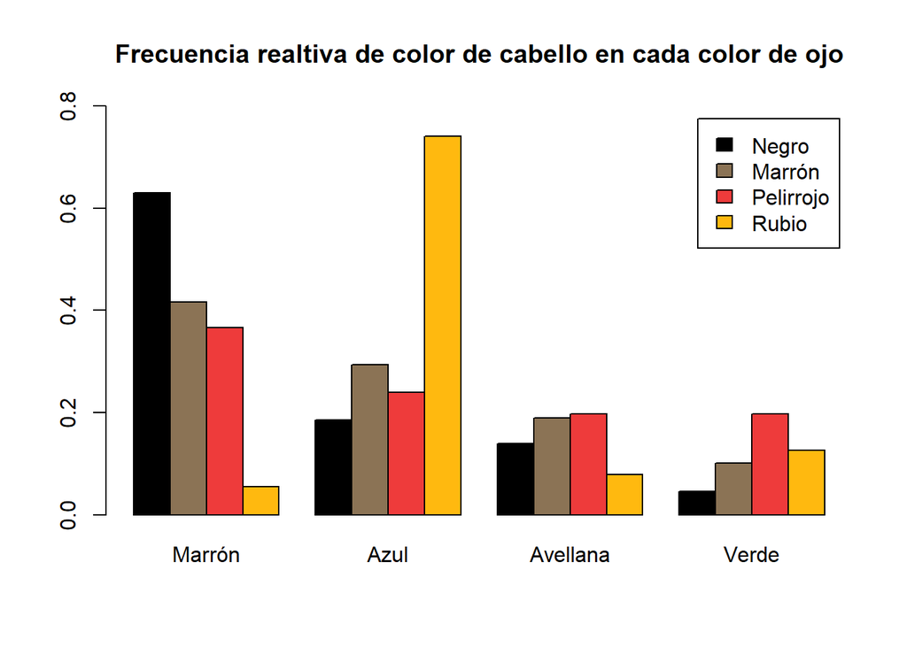

```r
barplot(prop.table(data, margin = 1), beside = T,
        col = c("black", "burlywood4", "brown2","darkgoldenrod1"),
        legend.text = T,
        main = "Frecuencia realtiva de color de cabello en cada color de ojo",
        ylim = c(0, 0.8))
```

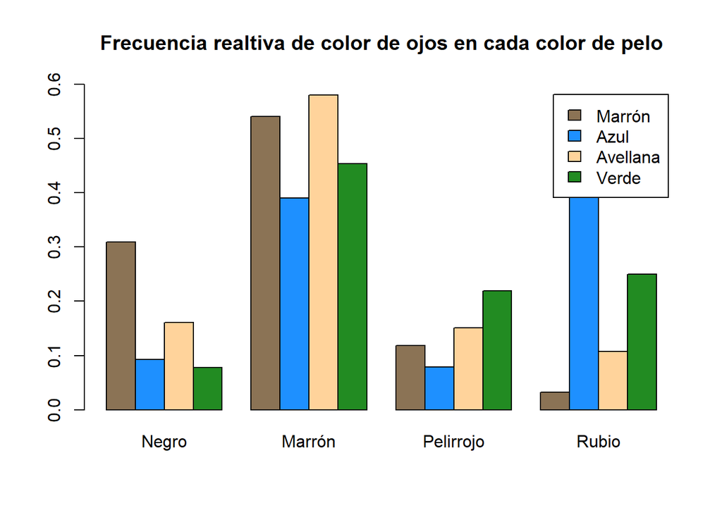

```r
barplot(t(prop.table(data, margin = 2)), beside = T,
        col = c("burlywood4", "dodgerblue","burlywood1", "forestgreen"),
        legend.text = T,
        main = "Frecuencia realtiva de color de ojos en cada color de pelo",
        ylim = c(0, 0.6))
```